# **第七章：生态数据的空间分析**

```r
# 解释空间变化:
# 使用Shapiro-Wilk残差正态性检验 - 对环境变量的显著性的典范轴进行回归
mite.rda2.axis1.env <- lm(mite.rda2.axes[ ,1] ~ ., data = mite.env)
# resid 计算残差
# https://www.rdocumentation.org/packages/stats/versions/3.5.2/topics/shapiro.test
# Shapiro-Wilk Normality Test - 正态性检验
shapiro.test(resid(mite.rda2.axis1.env))
```

```
##
##  Shapiro-Wilk normality test
##
## data:  resid(mite.rda2.axis1.env)
## W = 0.98357, p-value = 0.4902
```

```r
summary(mite.rda2.axis1.env)
```

```
##
## Call:
## lm(formula = mite.rda2.axes[, 1] ~ ., data = mite.env)
##
## Residuals:
##       Min        1Q    Median        3Q       Max
## -0.244653 -0.057331 -0.001444  0.053744  0.196436
##
## Coefficients:
##                      Estimate Std. Error t value Pr(>|t|)
## (Intercept)        -1.346e-01  1.052e-01  -1.279   0.2061
## SubsDens            3.042e-03  1.201e-03   2.532   0.0141 *
## WatrCont            5.024e-05  1.156e-04   0.435   0.6654
## SubstrateInterface  4.459e-02  7.243e-02   0.616   0.5406
## SubstrateLitter     1.483e-01  9.542e-02   1.554   0.1256
## SubstrateSphagn1    4.515e-02  7.366e-02   0.613   0.5424
## SubstrateSphagn2    3.755e-02  7.466e-02   0.503   0.6169
## SubstrateSphagn3    2.052e-01  1.243e-01   1.651   0.1041
## SubstrateSphagn4   -1.025e-01  9.776e-02  -1.048   0.2988
## ShrubMany          -8.502e-02  2.764e-02  -3.076   0.0032 **
## ShrubNone          -4.719e-02  3.393e-02  -1.391   0.1696
## TopoHummock        -1.565e-02  3.052e-02  -0.513   0.6099
## ---
## Signif. codes:  0 '***' 0.001 '**' 0.01 '*' 0.05 '.' 0.1 ' ' 1
##
## Residual standard error: 0.09184 on 58 degrees of freedom
## Multiple R-squared:  0.4101, Adjusted R-squared:  0.2982
## F-statistic: 3.666 on 11 and 58 DF,  p-value: 0.0005577
```

```r
mite.rda2.axis2.env <- lm(mite.rda2.axes[ ,2] ~ ., data = mite.env)
# resid 计算残差
# https://www.rdocumentation.org/packages/stats/versions/3.5.2/topics/shapiro.test
# Shapiro-Wilk Normality Test - 正态性检验
shapiro.test(resid(mite.rda2.axis2.env))
```

```
##
##  Shapiro-Wilk normality test
##
## data:  resid(mite.rda2.axis2.env)
## W = 0.97947, p-value = 0.3054
```

```r
summary(mite.rda2.axis2.env)
```

```
##
## Call:
## lm(formula = mite.rda2.axes[, 2] ~ ., data = mite.env)
##
## Residuals:
##      Min       1Q   Median       3Q      Max
## -0.10639 -0.03525 -0.00051  0.03821  0.11541
##
## Coefficients:
##                      Estimate Std. Error t value Pr(>|t|)
## (Intercept)         1.393e-01  6.644e-02   2.097  0.04039 *
## SubsDens           -1.095e-03  7.583e-04  -1.444  0.15415
## WatrCont           -4.857e-05  7.296e-05  -0.666  0.50823
## SubstrateInterface -1.970e-02  4.573e-02  -0.431  0.66828
## SubstrateLitter    -7.796e-02  6.024e-02  -1.294  0.20074
## SubstrateSphagn1   -3.611e-02  4.651e-02  -0.776  0.44065
## SubstrateSphagn2    1.979e-02  4.713e-02   0.420  0.67607
## SubstrateSphagn3   -1.373e-01  7.845e-02  -1.750  0.08544 .
## SubstrateSphagn4    5.693e-03  6.171e-02   0.092  0.92682
## ShrubMany          -8.581e-03  1.745e-02  -0.492  0.62472
## ShrubNone          -9.322e-02  2.142e-02  -4.352 5.55e-05 ***
## TopoHummock        -7.157e-02  1.927e-02  -3.714  0.00046 ***
## ---
## Signif. codes:  0 '***' 0.001 '**' 0.01 '*' 0.05 '.' 0.1 ' ' 1
##
## Residual standard error: 0.05798 on 58 degrees of freedom
## Multiple R-squared:  0.418,  Adjusted R-squared:  0.3076
## F-statistic: 3.787 on 11 and 58 DF,  p-value: 0.0004079
```

```r
# 根据置换的 p-value, 第三轴可能不重要.
# 在本示例中, 以下 3 行可能会报错
mite.rda2.axis3.env <- lm(mite.rda2.axes[ ,2] ~ ., data = mite.env)
# resid 计算残差
# https://www.rdocumentation.org/packages/stats/versions/3.5.2/topics/shapiro.test
# Shapiro-Wilk Normality Test - 正态性检验
shapiro.test(resid(mite.rda2.axis3.env))
```

```
##
##  Shapiro-Wilk normality test
##
## data:  resid(mite.rda2.axis3.env)
## W = 0.97947, p-value = 0.3054
```

```r
summary(mite.rda2.axis3.env)
```

```
##
## Call:
## lm(formula = mite.rda2.axes[, 2] ~ ., data = mite.env)
##
## Residuals:
##      Min       1Q   Median       3Q      Max
## -0.10639 -0.03525 -0.00051  0.03821  0.11541
##
## Coefficients:
##                      Estimate Std. Error t value Pr(>|t|)
## (Intercept)         1.393e-01  6.644e-02   2.097  0.04039 *
## SubsDens           -1.095e-03  7.583e-04  -1.444  0.15415
## WatrCont           -4.857e-05  7.296e-05  -0.666  0.50823
## SubstrateInterface -1.970e-02  4.573e-02  -0.431  0.66828
## SubstrateLitter    -7.796e-02  6.024e-02  -1.294  0.20074
## SubstrateSphagn1   -3.611e-02  4.651e-02  -0.776  0.44065
## SubstrateSphagn2    1.979e-02  4.713e-02   0.420  0.67607
## SubstrateSphagn3   -1.373e-01  7.845e-02  -1.750  0.08544 .
## SubstrateSphagn4    5.693e-03  6.171e-02   0.092  0.92682
## ShrubMany          -8.581e-03  1.745e-02  -0.492  0.62472
## ShrubNone          -9.322e-02  2.142e-02  -4.352 5.55e-05 ***
## TopoHummock        -7.157e-02  1.927e-02  -3.714  0.00046 ***
## ---
## Signif. codes:  0 '***' 0.001 '**' 0.01 '*' 0.05 '.' 0.1 ' ' 1
##
## Residual standard error: 0.05798 on 58 degrees of freedom
## Multiple R-squared:  0.418,  Adjusted R-squared:  0.3076
## F-statistic: 3.787 on 11 and 58 DF,  p-value: 0.0004079
```

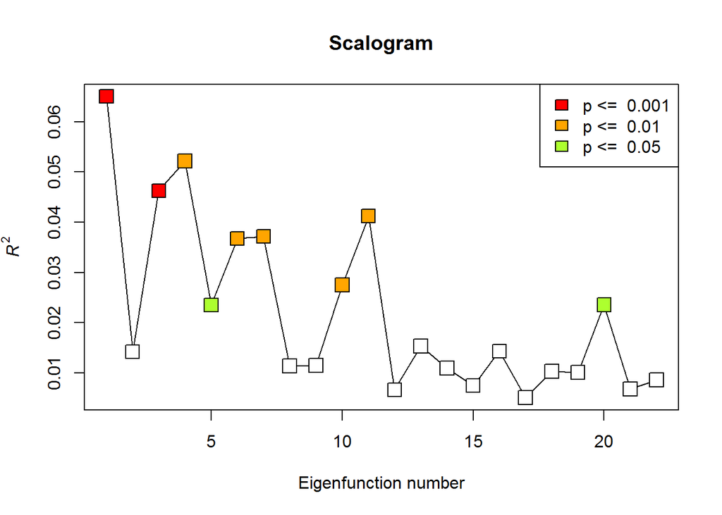

```r
# 绘制由所有 dbMEM 本征函数解释的 方差的尺度图 - Scalogram
# scalog() 自备函数
scalog(mite.dbmem.rda)
```

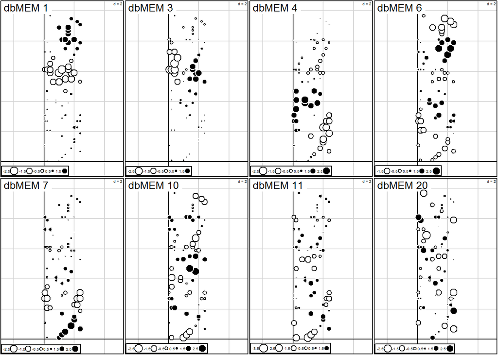

```r
# 绘制 8 个显著性的 dbMEN 变量的地图
# 使用自备函数 sr.value()
par(mfrow = c(2, 4))
for(i in 1 : ncol(dbmem.red)) {
    sr.value(mite.xy,
             dbmem.red[ ,i],
             # sub = paste("dbMEM",i),
             sub = paste("dbMEM",dbmem.sign[i]),
             csub = 2)
  }
```

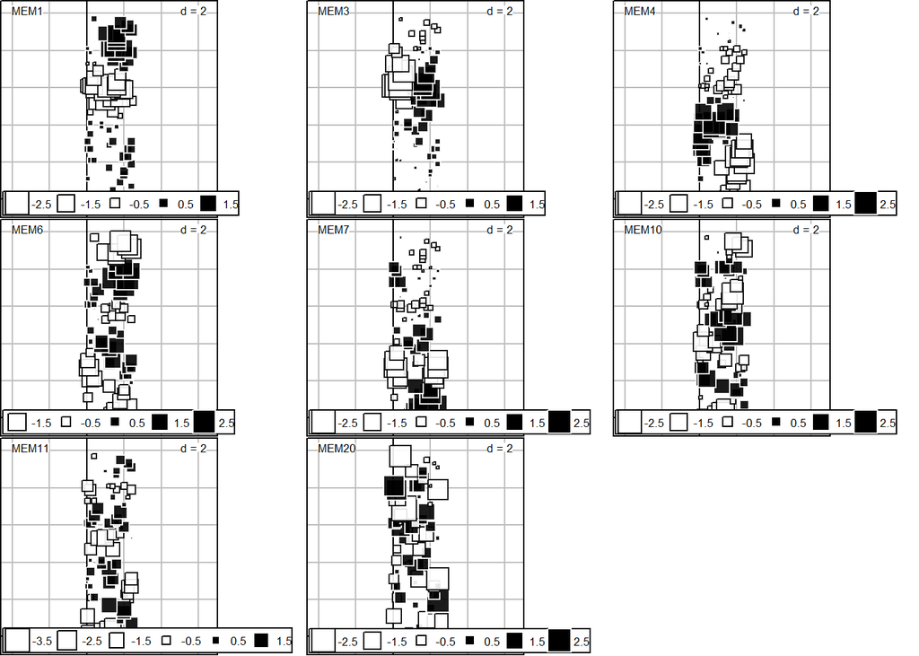

```r
# 散点图来表示变量值
s.value(mite.xy, dbmem.red)
```

```r
## 对螨虫数据集的 dbMEN 分析 - 大规模 broad scale
(mite.dbmem.broad <-
  rda(mite.h.det ~ ., data = mite.dbmem[ ,c(1,3,4)]))
```

```
## Call: rda(formula = mite.h.det ~ MEM1 + MEM3 + MEM4, data =
## mite.dbmem[, c(1, 3, 4)])
##
##               Inertia Proportion Rank
## Total         0.28235    1.00000
## Constrained   0.04616    0.16348    3
## Unconstrained 0.23619    0.83652   35
## Inertia is variance
##
## Eigenvalues for constrained axes:
##    RDA1    RDA2    RDA3
## 0.02810 0.01669 0.00137
##
## Eigenvalues for unconstrained axes:
##     PC1     PC2     PC3     PC4     PC5     PC6     PC7     PC8
## 0.06944 0.03081 0.02131 0.01660 0.01230 0.01114 0.00917 0.00822
## (Showing 8 of 35 unconstrained eigenvalues)
```

```r
anova(mite.dbmem.broad)
```

```
## Permutation test for rda under reduced model
## Permutation: free
## Number of permutations: 999
##
## Model: rda(formula = mite.h.det ~ MEM1 + MEM3 + MEM4, data = mite.dbmem[, c(1, 3, 4)])
##          Df Variance      F Pr(>F)
## Model     3  0.04616 4.2996  0.001 ***
## Residual 66  0.23619
## ---
## Signif. codes:  0 '***' 0.001 '**' 0.01 '*' 0.05 '.' 0.1 ' ' 1
```

```r
(axes.broad <- anova(mite.dbmem.broad, by = "axis"))
```

```
## Permutation test for rda under reduced model
## Forward tests for axes
## Permutation: free
## Number of permutations: 999
##
## Model: rda(formula = mite.h.det ~ MEM1 + MEM3 + MEM4, data = mite.dbmem[, c(1, 3, 4)])
##          Df Variance      F Pr(>F)
## RDA1      1  0.02810 7.8521  0.001 ***
## RDA2      1  0.01669 4.6638  0.001 ***
## RDA3      1  0.00137 0.3829  0.978
## Residual 66  0.23619
## ---
## Signif. codes:  0 '***' 0.001 '**' 0.01 '*' 0.05 '.' 0.1 ' ' 1
```

```r
# 显著性轴的数量
(nb.ax.broad <-
  length(which(axes.broad[ , ncol(axes.broad)] <=  0.05)))
```

```
## [1] 2
```

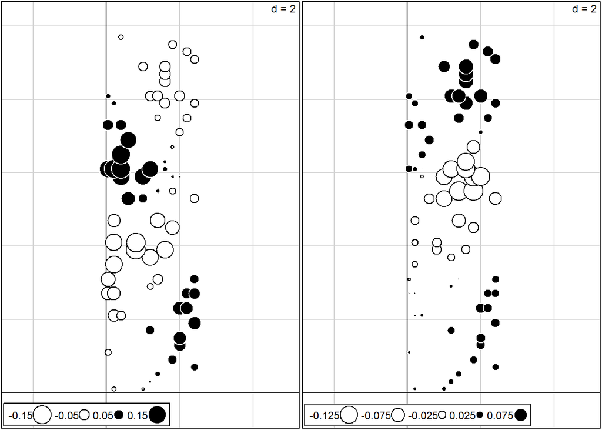

```r
# 绘制显著性的典范轴 - canonical axes
# 质心化 - 中心化处理矩阵(数据框)数据 - Centring
# scale() 对矩阵相似对象进行缩放或者居中
# https://www.rdocumentation.org/packages/base/versions/3.6.0/topics/scale
# 默认 center = T, 减去列平均值然后 centered
# center = F, 减去列平均值
mite.dbmembroad.axes <-
  scores(mite.dbmem.broad,
         choices = c(1,2),
         display = "lc",
         scaling = 1)

par(mfrow = c(1, 2))
# 使用自备函数 sr.value() - 绘图
sr.value(mite.xy, mite.dbmembroad.axes[ ,1])
sr.value(mite.xy, mite.dbmembroad.axes[ ,2])
```

```r
# 解释广义的空间变化 - broad-scaled spatial variation: 两个显著性的空间典范轴(spatial canonical axes)对环境变量的回归
mite.dbmembroad.ax1.env <-   lm(mite.dbmembroad.axes[ ,1] ~ ., data = mite.env)
summary(mite.dbmembroad.ax1.env)
```

```
##
## Call:
## lm(formula = mite.dbmembroad.axes[, 1] ~ ., data = mite.env)
##
## Residuals:
##       Min        1Q    Median        3Q       Max
## -0.132627 -0.046828  0.003272  0.043590  0.157836
##
## Coefficients:
##                      Estimate Std. Error t value Pr(>|t|)
## (Intercept)         1.299e-02  7.654e-02   0.170  0.86580
## SubsDens            8.292e-04  8.736e-04   0.949  0.34646
## WatrCont            5.642e-05  8.405e-05   0.671  0.50473
## SubstrateInterface -5.810e-03  5.268e-02  -0.110  0.91256
## SubstrateLitter     1.267e-02  6.939e-02   0.183  0.85575
## SubstrateSphagn1    7.286e-03  5.357e-02   0.136  0.89230
## SubstrateSphagn2   -2.251e-02  5.430e-02  -0.415  0.68000
## SubstrateSphagn3    6.961e-02  9.037e-02   0.770  0.44425
## SubstrateSphagn4   -9.979e-02  7.110e-02  -1.404  0.16578
## ShrubMany          -3.828e-02  2.010e-02  -1.904  0.06182 .
## ShrubNone          -8.319e-02  2.468e-02  -3.371  0.00134 **
## TopoHummock        -7.488e-02  2.220e-02  -3.373  0.00133 **
## ---
## Signif. codes:  0 '***' 0.001 '**' 0.01 '*' 0.05 '.' 0.1 ' ' 1
##
## Residual standard error: 0.06679 on 58 degrees of freedom
## Multiple R-squared:  0.411,  Adjusted R-squared:  0.2993
## F-statistic: 3.679 on 11 and 58 DF,  p-value: 0.0005389
```

```r
mite.dbmembroad.ax2.env <-  lm(mite.dbmembroad.axes[ ,2] ~ ., data = mite.env)
summary(mite.dbmembroad.ax2.env)
```

```
##
## Call:
## lm(formula = mite.dbmembroad.axes[, 2] ~ ., data = mite.env)
##
## Residuals:
##       Min        1Q    Median        3Q       Max
## -0.105833 -0.026686  0.003245  0.029955  0.096007
##
## Coefficients:
##                      Estimate Std. Error t value Pr(>|t|)
## (Intercept)        -6.253e-02  5.439e-02  -1.150 0.254945
## SubsDens            8.651e-04  6.207e-04   1.394 0.168679
## WatrCont           -7.020e-06  5.972e-05  -0.118 0.906839
## SubstrateInterface -2.980e-02  3.743e-02  -0.796 0.429231
## SubstrateLitter    -1.197e-03  4.931e-02  -0.024 0.980721
## SubstrateSphagn1   -2.593e-02  3.807e-02  -0.681 0.498543
## SubstrateSphagn2   -5.525e-02  3.858e-02  -1.432 0.157491
## SubstrateSphagn3    4.731e-02  6.421e-02   0.737 0.464191
## SubstrateSphagn4   -6.017e-02  5.051e-02  -1.191 0.238428
## ShrubMany           2.395e-02  1.428e-02   1.677 0.098996 .
## ShrubNone           1.147e-01  1.753e-02   6.544  1.7e-08 ***
## TopoHummock         5.989e-02  1.577e-02   3.797 0.000352 ***
## ---
## Signif. codes:  0 '***' 0.001 '**' 0.01 '*' 0.05 '.' 0.1 ' ' 1
##
## Residual standard error: 0.04746 on 58 degrees of freedom
## Multiple R-squared:  0.4994, Adjusted R-squared:  0.4044
## F-statistic: 5.259 on 11 and 58 DF,  p-value: 1.082e-05
```

```r
## 对螨虫数据集的 dbMEN 分析 - 中等规模 medium scale
(mite.dbmem.med <-  rda(mite.h.det ~ ., data = mite.dbmem[ ,c(6,7,10,11)]))
```

```
## Call: rda(formula = mite.h.det ~ MEM6 + MEM7 + MEM10 + MEM11, data
## = mite.dbmem[, c(6, 7, 10, 11)])
##
##               Inertia Proportion Rank
## Total         0.28235    1.00000
## Constrained   0.04028    0.14264    4
## Unconstrained 0.24207    0.85736   35
## Inertia is variance
##
## Eigenvalues for constrained axes:
##     RDA1     RDA2     RDA3     RDA4
## 0.025091 0.011005 0.002379 0.001801
##
## Eigenvalues for unconstrained axes:
##     PC1     PC2     PC3     PC4     PC5     PC6     PC7     PC8
## 0.07195 0.03266 0.02664 0.01462 0.01256 0.01057 0.00948 0.00828
## (Showing 8 of 35 unconstrained eigenvalues)
```

```r
anova(mite.dbmem.med)
```

```
## Permutation test for rda under reduced model
## Permutation: free
## Number of permutations: 999
##
## Model: rda(formula = mite.h.det ~ MEM6 + MEM7 + MEM10 + MEM11, data = mite.dbmem[, c(6, 7, 10, 11)])
##          Df Variance      F Pr(>F)
## Model     4 0.040275 2.7036  0.001 ***
## Residual 65 0.242074
## ---
## Signif. codes:  0 '***' 0.001 '**' 0.01 '*' 0.05 '.' 0.1 ' ' 1
```

```r
(axes.med <- anova(mite.dbmem.med, by = "axis"))
```

```
## Permutation test for rda under reduced model
## Forward tests for axes
## Permutation: free
## Number of permutations: 999
##
## Model: rda(formula = mite.h.det ~ MEM6 + MEM7 + MEM10 + MEM11, data = mite.dbmem[, c(6, 7, 10, 11)])
##          Df Variance      F Pr(>F)
## RDA1      1 0.025091 6.7371  0.004 **
## RDA2      1 0.011005 2.9549  0.046 *
## RDA3      1 0.002379 0.6388  0.974
## RDA4      1 0.001801 0.4836  0.925
## Residual 65 0.242074
## ---
## Signif. codes:  0 '***' 0.001 '**' 0.01 '*' 0.05 '.' 0.1 ' ' 1
```

```r
# 统计显著性轴的数量
(nb.ax.med <- length(which(axes.med[ ,ncol(axes.med)] <=  0.05)))
```

```
## [1] 2
```

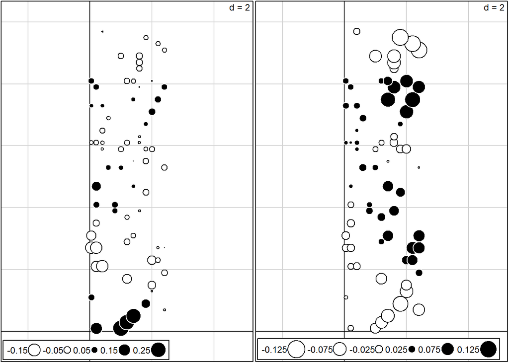

```r
# 绘制显著性的典范轴 - canonical axes
# 质心化 - 中心化处理矩阵(数据框)数据 - Centring
# scale() 对矩阵相似对象进行缩放或者居中
# https://www.rdocumentation.org/packages/base/versions/3.6.0/topics/scale
# 默认 center = T, 减去列平均值然后 centered
# center = F, 减去列平均值
mite.dbmemmed.axes <-
  scores(mite.dbmem.med,
         choices = c(1,2),
         display = "lc",
         scaling = 1)

par(mfrow = c(1, 2))
# 使用自备函数 sr.value() - 绘图
sr.value(mite.xy, mite.dbmemmed.axes[ ,1])
sr.value(mite.xy, mite.dbmemmed.axes[ ,2])
```

```r
# 解释中等尺度的空间变化：两个显著性的空间规范轴对环境变量的回归Interpreting the medium-scaled spatial variation: regression of the two significant spatial canonical axes on the environmental variables
mite.dbmemmed.ax1.env <-  lm(mite.dbmemmed.axes[ ,1] ~ ., data = mite.env)
summary(mite.dbmemmed.ax1.env)
```

```
##
## Call:
## lm(formula = mite.dbmemmed.axes[, 1] ~ ., data = mite.env)
##
## Residuals:
##      Min       1Q   Median       3Q      Max
## -0.18815 -0.03026 -0.00069  0.03346  0.18355
##
## Coefficients:
##                      Estimate Std. Error t value Pr(>|t|)
## (Intercept)        -1.218e-01  8.079e-02  -1.507   0.1372
## SubsDens            1.840e-03  9.220e-04   1.995   0.0507 .
## WatrCont           -4.959e-06  8.872e-05  -0.056   0.9556
## SubstrateInterface  4.044e-02  5.560e-02   0.727   0.4700
## SubstrateLitter     1.122e-01  7.324e-02   1.531   0.1311
## SubstrateSphagn1    3.646e-02  5.655e-02   0.645   0.5216
## SubstrateSphagn2    5.117e-02  5.731e-02   0.893   0.3756
## SubstrateSphagn3    6.617e-02  9.538e-02   0.694   0.4907
## SubstrateSphagn4   -8.605e-03  7.504e-02  -0.115   0.9091
## ShrubMany          -5.051e-02  2.122e-02  -2.380   0.0206 *
## ShrubNone           2.309e-02  2.605e-02   0.886   0.3790
## TopoHummock         6.118e-02  2.343e-02   2.612   0.0115 *
## ---
## Signif. codes:  0 '***' 0.001 '**' 0.01 '*' 0.05 '.' 0.1 ' ' 1
##
## Residual standard error: 0.0705 on 58 degrees of freedom
## Multiple R-squared:  0.2651, Adjusted R-squared:  0.1257
## F-statistic: 1.902 on 11 and 58 DF,  p-value: 0.05773
```

```r
mite.dbmemmed.ax2.env <-   lm(mite.dbmemmed.axes[ ,2] ~ ., data = mite.env)
summary(mite.dbmemmed.ax2.env)
```

```
##
## Call:
## lm(formula = mite.dbmemmed.axes[, 2] ~ ., data = mite.env)
##
## Residuals:
##       Min        1Q    Median        3Q       Max
## -0.093725 -0.027004  0.001544  0.028300  0.082174
##
## Coefficients:
##                      Estimate Std. Error t value Pr(>|t|)
## (Intercept)         9.719e-02  5.047e-02   1.925   0.0591 .
## SubsDens           -3.330e-04  5.760e-04  -0.578   0.5655
## WatrCont           -7.089e-05  5.543e-05  -1.279   0.2060
## SubstrateInterface -5.860e-02  3.474e-02  -1.687   0.0970 .
## SubstrateLitter    -9.875e-02  4.576e-02  -2.158   0.0351 *
## SubstrateSphagn1   -8.872e-02  3.533e-02  -2.511   0.0148 *
## SubstrateSphagn2   -3.556e-02  3.581e-02  -0.993   0.3248
## SubstrateSphagn3   -7.820e-02  5.959e-02  -1.312   0.1946
## SubstrateSphagn4   -5.599e-02  4.688e-02  -1.194   0.2372
## ShrubMany           2.647e-02  1.326e-02   1.997   0.0505 .
## ShrubNone           3.077e-02  1.627e-02   1.891   0.0636 .
## TopoHummock        -1.989e-02  1.464e-02  -1.359   0.1795
## ---
## Signif. codes:  0 '***' 0.001 '**' 0.01 '*' 0.05 '.' 0.1 ' ' 1
##
## Residual standard error: 0.04404 on 58 degrees of freedom
## Multiple R-squared:  0.346,  Adjusted R-squared:  0.222
## F-statistic:  2.79 on 11 and 58 DF,  p-value: 0.005579
```

```r
## 对螨虫数据集的 dbMEN 分析 - 精细规模 fine scale
(mite.dbmem.fine <-  rda(mite.h.det ~ ., data = as.data.frame(mite.dbmem[ ,20])))
```

```
## Call: rda(formula = mite.h.det ~ `mite.dbmem[, 20]`, data =
## as.data.frame(mite.dbmem[, 20]))
##
##                Inertia Proportion Rank
## Total         0.282349   1.000000
## Constrained   0.006659   0.023586    1
## Unconstrained 0.275690   0.976414   35
## Inertia is variance
##
## Eigenvalues for constrained axes:
##     RDA1
## 0.006659
##
## Eigenvalues for unconstrained axes:
##     PC1     PC2     PC3     PC4     PC5     PC6     PC7     PC8
## 0.09055 0.03432 0.02937 0.01628 0.01471 0.01185 0.01018 0.00831
## (Showing 8 of 35 unconstrained eigenvalues)
```

```r
anova(mite.dbmem.fine)
```

```
## Permutation test for rda under reduced model
## Permutation: free
## Number of permutations: 999
##
## Model: rda(formula = mite.h.det ~ `mite.dbmem[, 20]`, data = as.data.frame(mite.dbmem[, 20]))
##          Df Variance      F Pr(>F)
## Model     1 0.006659 1.6426  0.114
## Residual 68 0.275690
```

```r
#>>> 分析就此停止, 冗余分析的结果没有显著性
```

#### 7.4.2.4 Hassle-Free dbMEM Analysis: 函数 quickMEM()

- 一步到位.

quickMEM() 运行整套 PCNM 分析: 检验数据的趋势性, 如果趋势显著, 进行去趋势处理; 构建PCNM变量和检验RDA全模型显著性; 对正空间相关性的PCNM变量进行前向选择; 运行保留的PCNM变量的RDA分析并检验典型轴的显著性; 输出RDA结果(包括PCNM变量组)和绘制显著典型轴的空间地图.

```r
mite.dbmem.quick <- quickMEM(mite.h, mite.xy)
```

```
## Truncation level = 1.011188
## Time to compute dbMEMs = 0.000000  sec
## Testing variable 1
## Testing variable 2
## Testing variable 3
## Testing variable 4
## Testing variable 5
## Testing variable 6
## Testing variable 7
## Testing variable 8
## Testing variable 9
## Procedure stopped (adjR2thresh criteria) adjR2cum = 0.256211 with 9 variables (> 0.245443)
```

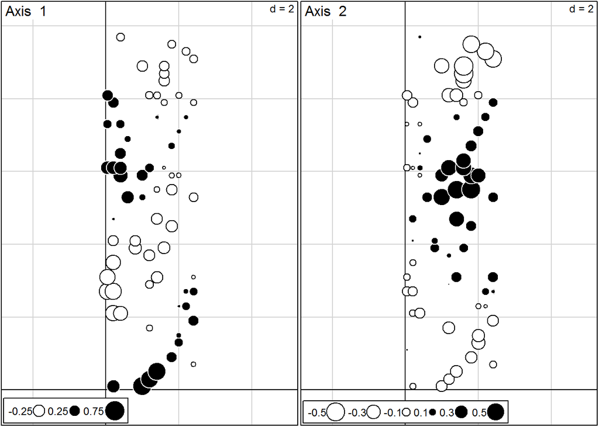

```
##
##  -------------------------------------------------------
##  A significant linear trend has been found in the response data.
##  The response data have been detrended prior to dbMEM analysis.
## -------------------------------------------------------
##   22 dbMEM eigenvectors have been produced
##   R2 of global model =  0.486
##   Adjusted R2 of global model =  0.2454
##   8  dbMEM eigenvectors have been selected
##   R2 of minimum (final) model =  0.3297
##   Adjusted R2 of minimum (final) model =  0.2418
##   The final model has 2 significant canonical axes
## ---------------------------------------------------------
##  Time to compute quickMEM = 2.120000  sec
```

```r
summary(mite.dbmem.quick)
```

```
##                 Length Class      Mode
## dbMEM           22     data.frame list
## eigenvalues     22     -none-     numeric
## fwd.sel          7     data.frame list
## dbMEM_red_model  8     data.frame list
## RDA             12     rda        list
## RDA_test         4     anova.cca  list
## RDA_axes_tests   4     anova.cca  list
```

```r
# 特征值
mite.dbmem.quick[[2]]  # OR mite.dbmem.quick$eigenvalues
```

```
##  [1] 0.120184629 0.099183533 0.079388529 0.074822451 0.062738076
##  [6] 0.059740195 0.052185419 0.050591746 0.035146498 0.032814871
## [11] 0.031770628 0.025092985 0.022929249 0.018141622 0.015567333
## [16] 0.012436381 0.011019395 0.008996037 0.006181531 0.006071314
## [21] 0.003352728 0.001023196
```

```r
# 前向选择的结果
mite.dbmem.quick[[3]]  # OR mite.dbmem.quick$fwd.sel
```

```
##   variables order         R2      R2Cum   AdjR2Cum        F pvalue
## 1      MEM1     1 0.06504057 0.06504057 0.05129117 4.730429  0.001
## 2      MEM4     4 0.05218426 0.11722483 0.09087333 3.960629  0.004
## 3      MEM3     3 0.04626011 0.16348494 0.12546152 3.649865  0.001
## 4     MEM11    11 0.04121302 0.20469795 0.15575629 3.368338  0.003
## 5      MEM7     7 0.03716078 0.24185873 0.18262894 3.137001  0.003
## 6      MEM6     6 0.03676504 0.27862377 0.20992127 3.210804  0.002
## 7     MEM10    10 0.02750409 0.30612786 0.22778746 2.457590  0.013
## 8     MEM20    20 0.02358552 0.32971338 0.24180693 2.146420  0.027
```

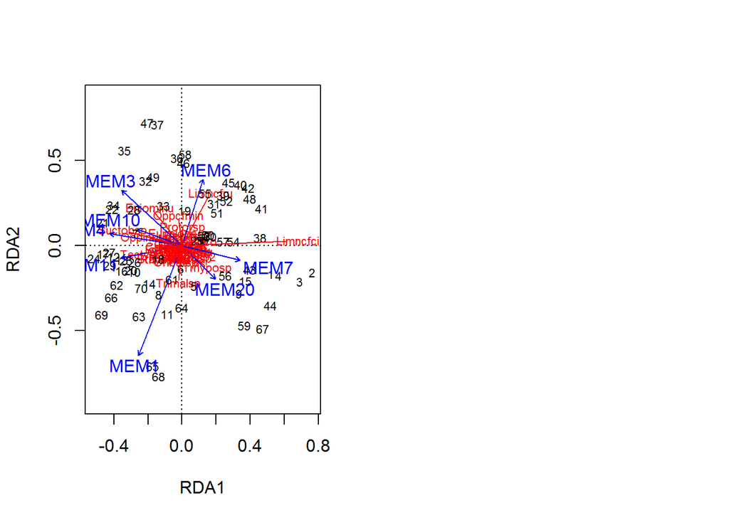

```r
plot(mite.dbmem.quick$RDA, scaling = 2)
# 质心化 - 中心化处理矩阵(数据框)数据 - Centring
# scale() 对矩阵相似对象进行缩放或者居中
# https://www.rdocumentation.org/packages/base/versions/3.6.0/topics/scale
# 默认 center = T, 减去列平均值然后 centered
# center = F, 减去列平均值
sp.scores2 <-
  scores(mite.dbmem.quick$RDA,
         choices = 1:2,
         scaling = 2,
         display = "sp")
arrows(0, 0,
  sp.scores2[ ,1] * 0.9,
  sp.scores2[ ,2] * 0.9,
  length = 0,
  lty = 1,
  col = "red")
```

#### 7.4.2.5 结合基于距离的 Moran 特征向量图分析 & 方差分解(Variation Partitioning)

方差分解可以用于评估环境变量与所有尺度的空间变量对响应变量的解释程度. 方差分解的函数 varpart() 只能识别数值型变量(非因子), 因此, 计算时必须重新编码, 使之成为二元变量.

变差分解的目的是量化各种不同因素单独或者共同解释响应变量变差的比例, 其中线性趋势可以视为产生方差的一部分来源. 线性趋势可以发生在响应变量, 也可以发生在解释变量. 因此, 不建议在方差分解之前对响应变量进行去趋势处理, 但需要检验线性趋势的显著性, 如果趋势显著, 方差分解过程中应该考虑线性趋势的影响.

```r
# 1. 检验趋势 - Test trend
mite.XY.rda <- rda(mite.h, mite.xy)
anova(mite.XY.rda)
```

```
## Permutation test for rda under reduced model
## Permutation: free
## Number of permutations: 999
##
## Model: rda(X = mite.h, Y = mite.xy)
##          Df Variance     F Pr(>F)
## Model     2  0.11193 13.28  0.001 ***
## Residual 67  0.28235
## ---
## Signif. codes:  0 '***' 0.001 '**' 0.01 '*' 0.05 '.' 0.1 ' ' 1
```

```r
# 2. 检验环境变量的前向选择 - Test and forward selection of the environmental variables
# 将环境变量3到5重新编码为虚拟二进制变量
# https://www.rdocumentation.org/packages/stats/versions/3.6.0/topics/model.matrix
substrate <- model.matrix( ~ mite.env[ ,3])[ ,-1]
shrubs <- model.matrix( ~ mite.env[ ,4])[ ,-1]
topography <- model.matrix( ~ mite.env[ ,5])[ ,-1]
mite.env2 <- cbind(mite.env[ ,1:2], substrate, shrubs, topography)
colnames(mite.env2) <-
  c("SubsDens", "WatrCont", "Interface", "Litter", "Sphagn1",
    "Sphagn2", "Sphagn3", "Sphagn4", "Shrubs_Many", "Shrubs_None",
    "topography")
# 环境变量的前向选择
# https://www.rdocumentation.org/packages/vegan/versions/2.4-2/topics/cca
mite.env.rda <- rda(mite.h ~., mite.env2)
# https://www.rdocumentation.org/packages/vegan/versions/2.4-2/topics/RsquareAdj
(mite.env.R2a <- RsquareAdj(mite.env.rda)$adj.r.squared)
```

```
## [1] 0.4367038
```

```r
# https://www.rdocumentation.org/packages/adespatial/versions/0.3-4/topics/forward.sel
# 在缩减模式(reduced model)下通过残差的置换进行前向选择
mite.env.fwd <-
  forward.sel(mite.h, mite.env2,
              adjR2thresh = mite.env.R2a,
              nperm = 9999)
```

```
## Testing variable 1
## Testing variable 2
## Testing variable 3
## Testing variable 4
## Testing variable 5
## Testing variable 6
## Testing variable 7
## Procedure stopped (alpha criteria): pvalue for variable 7 is 0.064900 (> 0.050000)
```

```r
env.sign <- sort(mite.env.fwd$order)
env.red <- mite.env2[ ,c(env.sign)]
colnames(env.red)
```

```
## [1] "SubsDens"    "WatrCont"    "Sphagn1"     "Shrubs_Many" "Shrubs_None"
## [6] "topography"
```

```r
# 3. dbMEN 变量的检验和前向选择
# 对'去势'后的螨虫数据集进行全局 dbMEN 分析
mite.det.dbmem.rda <- rda(mite.h.det ~., mite.dbmem)
anova(mite.det.dbmem.rda)
```

```
## Permutation test for rda under reduced model
## Permutation: free
## Number of permutations: 999
##
## Model: rda(formula = mite.h.det ~ MEM1 + MEM2 + MEM3 + MEM4 + MEM5 + MEM6 + MEM7 + MEM8 + MEM9 + MEM10 + MEM11 + MEM12 + MEM13 + MEM14 + MEM15 + MEM16 + MEM17 + MEM18 + MEM19 + MEM20 + MEM21 + MEM22, data = mite.dbmem)
##          Df Variance      F Pr(>F)
## Model    22  0.13723 2.0202  0.001 ***
## Residual 47  0.14512
## ---
## Signif. codes:  0 '***' 0.001 '**' 0.01 '*' 0.05 '.' 0.1 ' ' 1
```

```r
# 因为分析结果呈现显著性, 所以计算调整后的R方并进行 dbMEN 变量的前向选择
(mite.det.dbmem.R2a <-
  RsquareAdj(mite.det.dbmem.rda)$adj.r.squared)
```

```
## [1] 0.2454429
```

```r
(mite.det.dbmem.fwd <-
  forward.sel(mite.h.det,
              as.matrix(mite.dbmem),
    adjR2thresh = mite.det.dbmem.R2a))
```

```
## Testing variable 1
## Testing variable 2
## Testing variable 3
## Testing variable 4
## Testing variable 5
## Testing variable 6
## Testing variable 7
## Testing variable 8
## Testing variable 9
## Procedure stopped (adjR2thresh criteria) adjR2cum = 0.256211 with 9 variables (> 0.245443)
```

```
##   variables order         R2      R2Cum   AdjR2Cum        F pvalue
## 1      MEM1     1 0.06504057 0.06504057 0.05129117 4.730429  0.002
## 2      MEM4     4 0.05218426 0.11722483 0.09087333 3.960629  0.003
## 3      MEM3     3 0.04626011 0.16348494 0.12546152 3.649865  0.002
## 4     MEM11    11 0.04121302 0.20469795 0.15575629 3.368338  0.003
## 5      MEM7     7 0.03716078 0.24185873 0.18262894 3.137001  0.003
## 6      MEM6     6 0.03676504 0.27862377 0.20992127 3.210804  0.003
## 7     MEM10    10 0.02750409 0.30612786 0.22778746 2.457590  0.013
## 8     MEM20    20 0.02358552 0.32971338 0.24180693 2.146420  0.023
```

```r
# 统计显著的 dbMEN 数量
(nb.sig.dbmem <- nrow(mite.det.dbmem.fwd))
```

```
## [1] 8
```

```r
# 升序筛选并识别显著的 dbMEN 结果
(dbmem.sign <- sort(mite.det.dbmem.fwd$order))
```

```
## [1]  1  3  4  6  7 10 11 20
```

```r
# 存储显著性结果
dbmem.red <- mite.dbmem[ ,c(dbmem.sign)]

# 4. 任意(Arbitrarily)将显著性的 dbMEM 划分为广泛和精细的规模
# 大规模 - Broad scale: dbMEM 1, 3, 4, 6, 7
dbmem.broad <- dbmem.red[ , 1 : 5]
# 精细规模 - Fine scale: dbMEM 10, 11, 20
dbmem.fine <- dbmem.red[ , 6 : 8]

## 5. Mite - environment - trend - dbMEM  方差分解(variation partitioning)
# varpart() 方差分解
# https://www.rdocumentation.org/packages/vegan/versions/2.4-2/topics/varpart
(mite.varpart <-
  varpart(mite.h, env.red, mite.xy, dbmem.broad, dbmem.fine))
```

```
##
## Partition of variance in RDA
##
## Call: varpart(Y = mite.h, X = env.red, mite.xy, dbmem.broad,
## dbmem.fine)
##
## Explanatory tables:
## X1:  env.red
## X2:  mite.xy
## X3:  dbmem.broad
## X4:  dbmem.fine
##
## No. of explanatory tables: 4
## Total variation (SS): 27.205
##             Variance: 0.39428
## No. of observations: 70
##
## Partition table:
##                             Df R.square Adj.R.square Testable
## [aeghklno] = X1              6  0.45992      0.40849     TRUE
## [befiklmo] = X2              2  0.28388      0.26250     TRUE
## [cfgjlmno] = X3              5  0.18992      0.12664     TRUE
## [dhijkmno] = X4              3  0.05079      0.00765     TRUE
## [abefghiklmno] = X1+X2       8  0.50586      0.44105     TRUE
## [acefghjklmno] = X1+X3      11  0.55713      0.47313     TRUE
## [adeghijklmno] = X1+X4       9  0.49848      0.42325     TRUE
## [bcefgijklmno] = X2+X3       7  0.46287      0.40222     TRUE
## [bdefhijklmno] = X2+X4       5  0.35225      0.30164     TRUE
## [cdfghijklmno] = X3+X4       8  0.24072      0.14114     TRUE
## [abcefghijklmno] = X1+X2+X3 13  0.60156      0.50906     TRUE
## [abdefghijklmno] = X1+X2+X4 11  0.54160      0.45466     TRUE
## [acdefghijklmno] = X1+X3+X4 14  0.59197      0.48810     TRUE
## [bcdefghijklmno] = X2+X3+X4 10  0.53136      0.45193     TRUE
## [abcdefghijklmno] = All     16  0.63492      0.52471     TRUE
## Individual fractions
## [a] = X1 | X2+X3+X4          6               0.07278     TRUE
## [b] = X2 | X1+X3+X4          2               0.03660     TRUE
## [c] = X3 | X1+X2+X4          5               0.07005     TRUE
## [d] = X4 | X1+X2+X3          3               0.01564     TRUE
## [e]                          0               0.27418    FALSE
```

[output cut: 24 more lines]

```
## Controlling 1 table X
## [aghn] = X1 | X2             6               0.17855     TRUE
## [aehk] = X1 | X3             6               0.34649     TRUE
## [aegl] = X1 | X4             6               0.41560     TRUE
## [bfim] = X2 | X1             2               0.03256     TRUE
## [beik] = X2 | X3             2               0.27558     TRUE
## [befl] = X2 | X4             2               0.29399     TRUE
## [cfjm] = X3 | X1             5               0.06464     TRUE
## [cgjn] = X3 | X2             5               0.13972     TRUE
## [cfgl] = X3 | X4             5               0.13349     TRUE
## [dijm] = X4 | X1             3               0.01476     TRUE
## [dhjn] = X4 | X2             3               0.03914     TRUE
## [dhik] = X4 | X3             3               0.01450     TRUE
## ---
## Use function 'rda' to test significance of fractions of interest
```

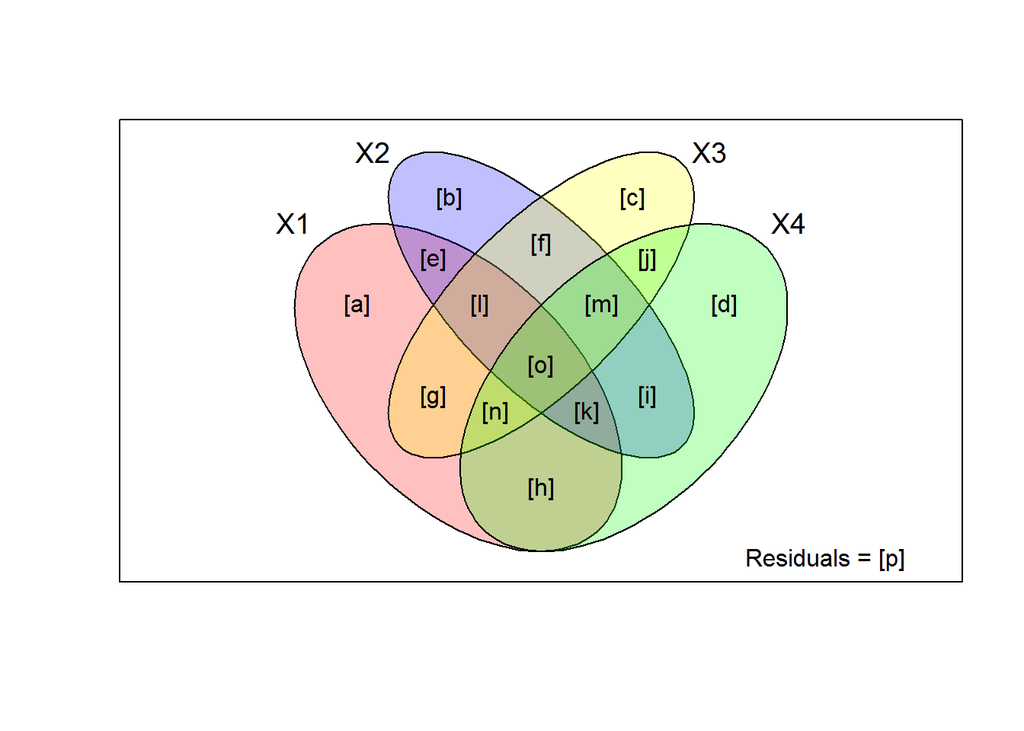

```r
# https://www.rdocumentation.org/packages/vegan/versions/2.4-2/topics/varpart
# par(mfrow = c(1,2))
showvarparts(4, bg = c("red", "blue", "yellow", "green"))
```

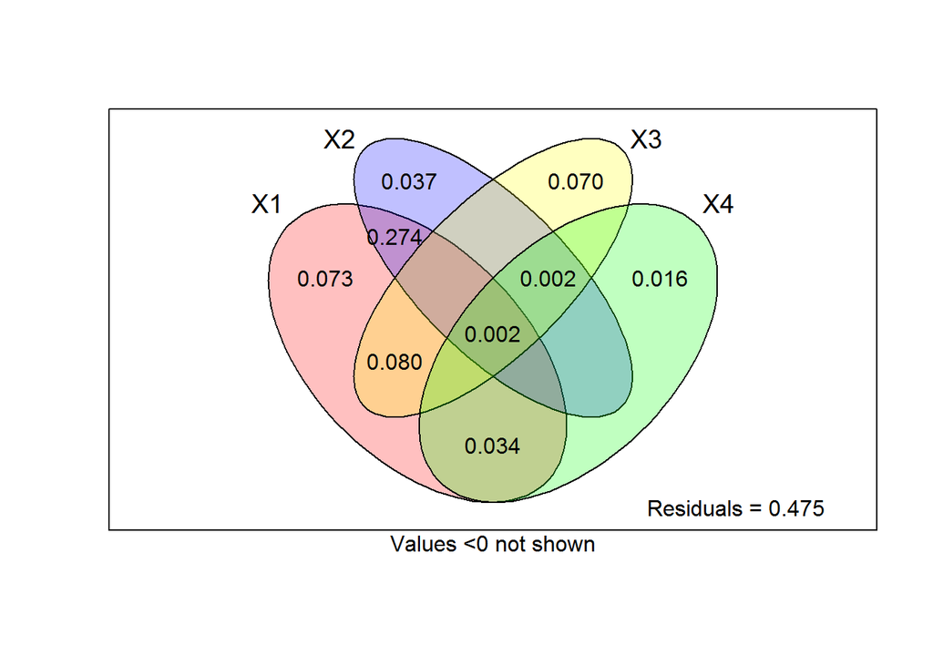

```r
plot(mite.varpart,
     digits = 2,
     bg = c("red", "blue", "yellow", "green")
     )
```

```r
# 检测独特分数(unique fractions) [a], [b], [c], [d]
# Fraction [a], pure environmental
anova(
  rda(mite.h, env.red, cbind(mite.xy, dbmem.broad, dbmem.fine))
  )
```

```
## Permutation test for rda under reduced model
## Permutation: free
## Number of permutations: 999
##
## Model: rda(X = mite.h, Y = env.red, Z = cbind(mite.xy, dbmem.broad, dbmem.fine))
##          Df Variance      F Pr(>F)
## Model     6 0.040832 2.5057  0.001 ***
## Residual 53 0.143942
## ---
## Signif. codes:  0 '***' 0.001 '**' 0.01 '*' 0.05 '.' 0.1 ' ' 1
```

```r
# Fraction [b], pure trend
anova(
  rda(mite.h, mite.xy, cbind(env.red, dbmem.broad, dbmem.fine))
  )
```

```
## Permutation test for rda under reduced model
## Permutation: free
## Number of permutations: 999
##
## Model: rda(X = mite.h, Y = mite.xy, Z = cbind(env.red, dbmem.broad, dbmem.fine))
##          Df Variance      F Pr(>F)
## Model     2 0.016936 3.1179  0.001 ***
## Residual 53 0.143942
## ---
## Signif. codes:  0 '***' 0.001 '**' 0.01 '*' 0.05 '.' 0.1 ' ' 1
```

```r
# Fraction [c], pure broad scale spatial
anova(rda
  (mite.h, dbmem.broad, cbind(env.red, mite.xy, dbmem.fine))
  )
```

```
## Permutation test for rda under reduced model
## Permutation: free
## Number of permutations: 999
##
## Model: rda(X = mite.h, Y = dbmem.broad, Z = cbind(env.red, mite.xy, dbmem.fine))
##          Df Variance      F Pr(>F)
## Model     5 0.036794 2.7095  0.001 ***
## Residual 53 0.143942
## ---
## Signif. codes:  0 '***' 0.001 '**' 0.01 '*' 0.05 '.' 0.1 ' ' 1
```

```r
# Fraction [d], pure fine scale spatial
anova(
  rda(mite.h, dbmem.fine, cbind(env.red, mite.xy, dbmem.broad))
  )
```

```
## Permutation test for rda under reduced model
## Permutation: free
## Number of permutations: 999
##
## Model: rda(X = mite.h, Y = dbmem.fine, Z = cbind(env.red, mite.xy, dbmem.broad))
##          Df Variance      F Pr(>F)
## Model     3 0.013153 1.6143  0.022 *
## Residual 53 0.143942
## ---
## Signif. codes:  0 '***' 0.001 '**' 0.01 '*' 0.05 '.' 0.1 ' ' 1
```

### 7.4.3 更广泛背景下的Moran 特征向量图分析方法(MEM): 地理距离以外的权重(Weights Other than Geographic Distances)

#### 7.4.3.1 简介

MEM 方法可以产生 n-1 个带正特征根或负特征根的空间变量, 即得到更大范围内模拟正负空间相关的空间变量. MEM 特征向量会使 Moran 指数最大化, 而特征根等于 Moran 指数乘以一个常数. 因此, 数据空间结构按照这样一种方式提取: 轴首先展示正的自相关结构(正相关程度递减), 然后哦展示负的自相关结构(负相关程度递增).

MEM 运算过程首先需要定义描述样方之间关系的两个矩阵: -1> 二元连接矩阵B: 定义样方对之间是否连接(连接为1, 不连接为0); -2> 权重矩阵A: 定义连接的强度. 最终的空间权重矩阵W是矩阵B和A的Hadamard积(即相同位置项的乘积).

#### 7.4.3.2 甲螨数据集的广义 MEM 分析 ( Moran 特征向量图 )

```r
## '去势'螨虫数据集的 Moran 特征向量图分析(MEM)

# 选择最优空间加权矩阵 - Selection of an optimal spatial weighting matrix

# 1. Search based on Delaunay triangulation.
# http://mathworld.wolfram.com/DelaunayTriangulation.html
# https://en.wikipedia.org/wiki/Delaunay_triangulation
# 将 mite.h.det 作为响应数据, 将 mite.del 作为 Delaunay triangulation 数据
# 非加权矩阵(binary weights only):
# 1 - 易于沟通 means connected (easy communication),
# 0 - 不可沟通 - not connected (无交流的可能 - no exchange  possible).
# 函数 test.W() 选择 Moran 特征向量图分析中的变量, 构建 Delaunay triangulation 分析的基础

# Delaunay triangulation 数据集 & 模型选择
# https://www.rdocumentation.org/packages/spdep/versions/1.1-2/topics/tri2nb
# 三个对象的邻近列表
# 将二维坐标矩阵转换为类 'nb' 的邻近列表
(mite.del <- tri2nb(mite.xy))
```

[output not shown]

```
## Neighbour list object:
## Number of regions: 70
## Number of nonzero links: 378
## Percentage nonzero weights: 7.714286
## Average number of links: 5.4
```

```r
# https://www.rdocumentation.org/packages/adespatial/versions/0.3-4/topics/test.W
# test.W - 计算和测试空间加权矩阵特征向量的函数
mite.del.res <-
  test.W(mite.h.det,
         mite.del,
         MEM.autocor = "positive")
```

```
##
##
## AICc for the null model: -87.47112034786
##
## Best spatial model:
##           AICc NbVar
## MEM5 -93.87049     6
```

```r
# 汇总最优模型的结果
summary(mite.del.res$best)
```

```
##     Length Class        Mode
## MEM 28     orthobasisSp list
## AIC  4     -none-       list
```

```r
# 未调整的 R方 - with the smallest AICc value
(R2.del <-
  mite.del.res$best$AIC$R2[which.min(mite.del.res$best$AIC$AICc)])
```

```
##      MEM5
## 0.2500992
```

```r
# 调整的 R方 - with the smallest AICc value
# https://www.rdocumentation.org/search?q=RsquareAdj&latest=
RsquareAdj(
  R2.del,
  n = nrow(mite.h.det),
  m = which.min(mite.del.res$best$AIC$AICc)
  )
```

```
##    MEM5
## 0.17868
```

```r
# 2. 通过距离对 Delaunay triangulation 进行加权.
# 距离最大值是 1, 提升效力至 - y.
# 进行数据转换之后, 接近 1 的表示易于交换(通信), 接近 0 的表示难于通信交流.
f2 <- function(D, dmax, y) {
  1 - (D/dmax)^y
  }

# 获取链接中最大的欧式距离(Euclidean distance)
# 该链接属于 Delaunay triangulation
max.d1 <- max(unlist(nbdists(mite.del, as.matrix(mite.xy))))
# 效力 - Power y 设置的范围 2 ~ 10
# https://www.rdocumentation.org/packages/adespatial/versions/0.3-4/topics/test.W
# test.W - 计算和测试空间加权矩阵特征向量的函数
mite.del.f2 <-
  test.W(mite.h.det, mite.del,
         MEM.autocor = "positive",
         f = f2,
         y = 2:10,
         dmax = max.d1,
         xy = as.matrix(mite.xy))
```

```
##
##
## AICc for the null model: -87.47112034786
##
## Best spatial model:
##   y dmax      AICc NbVar
## 1 2    3 -95.32388     4
```

```r
# 最优模型的未调整 R方
(R2.delW <-
  mite.del.f2$best$AIC$R2[which.min(mite.del.f2$best$AIC$AICc)])
```

```
##      MEM7
## 0.2126012
```

```r
# 最优模型的调整的R方
# https://www.rdocumentation.org/search?q=RsquareAdj&latest=
RsquareAdj(
  R2.delW,
  n = nrow(mite.h.det),
  m = which.min(mite.del.f2$best$AIC$AICc)
  )
```

```
##      MEM7
## 0.1641459
```

```r
# 3a. 基于距离连接矩阵（点周围半径）
# Connectivity matrix based on a distance (radius around points)
# 基于去趋势螨数据的多变量变异函数评估相关距离，具有20个距离等级
# variogmultiv() - 计算多元经验变异函数
# https://www.rdocumentation.org/packages/adespatial/versions/0.0-4/topics/variogmultiv
(mite.vario <- variogmultiv(mite.h.det,
                            mite.xy,
                            nclass = 20))# 距离类别数
```

```
## $d
##  [1] 0.2404683 0.7214049 1.2023415 1.6832781 2.1642146 2.6451512 3.1260878
##  [8] 3.6070244 4.0879610 4.5688976 5.0498342 5.5307707 6.0117073 6.4926439
## [15] 6.9735805 7.4545171 7.9354537 8.4163903 8.8973268 9.3782634
##
## $var
##  [1] 0.2049457 0.2326157 0.2416677 0.2544798 0.2829097 0.3204819 0.3202645
##  [8] 0.3360887 0.3288910 0.2791102 0.2964165 0.2709010 0.2479015 0.2624315
## [15] 0.2371314 0.2540558 0.2893112 0.3343251 0.3752431 0.4709336
##
## $n.c
##  [1] 61 67 70 69 70 70 70 70 70 70 70 66 60 47 43 37 26 18 13  9
##
## $n.w
##  [1]  63 135 245 223 272 235 180 189 138 113 134 102 117  65  71  49  35
## [18]  25  13  11
##
## $dclass
##  [1] "(0,0.481]"     "(0.481,0.962]" "(0.962,1.44]"  "(1.44,1.92]"
##  [5] "(1.92,2.4]"    "(2.4,2.89]"    "(2.89,3.37]"   "(3.37,3.85]"
##  [9] "(3.85,4.33]"   "(4.33,4.81]"   "(4.81,5.29]"   "(5.29,5.77]"
## [13] "(5.77,6.25]"   "(6.25,6.73]"   "(6.73,7.21]"   "(7.21,7.69]"
## [17] "(7.69,8.18]"   "(8.18,8.66]"   "(8.66,9.14]"   "(9.14,9.62]"
```

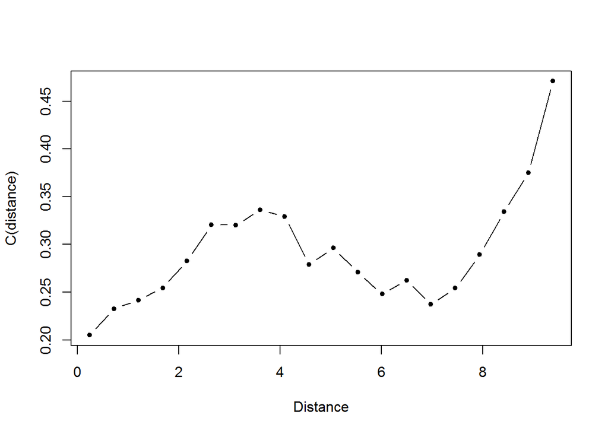

```r
plot(
  mite.vario$d,
  mite.vario$var,
  ty = 'b',
  pch = 20,
  xlab = "Distance",
  ylab = "C(distance)"
  )
```

```r
# 构建 10 个邻近矩阵 (class nb)
# 10 个阈值距离的向量
# https://www.rdocumentation.org/packages/adespatial/versions/0.3-4/topics/give.thresh
# give.thresh - 基于距离矩阵计算最小生成树的最大距离
(thresh10 <- seq(give.thresh(dist(mite.xy)), 4, le = 10))
```

```
##  [1] 1.011187 1.343278 1.675368 2.007458 2.339549 2.671639 3.003729
##  [8] 3.335819 3.667910 4.000000
```

```r
# 创建 10 个邻近矩阵
# 每个矩阵包含长度小于或等于阈值的所有连接
# https://www.rdocumentation.org/packages/base/versions/3.6.0/topics/lapply
list10nb <-
  lapply(thresh10, # 在列表或向量上应用函数
         dnearneigh,
         x = as.matrix(mite.xy),
         d1 = 0)
# 显示第一个邻域矩阵的'摘录'(excerpt )
# nb2listw & listw2mat - 该函数为具有所选编码方案的空间权重的邻近列表生成权重矩阵
# https://www.rdocumentation.org/packages/spdep/versions/1.1-2/topics/nb2mat
print(
  listw2mat(nb2listw(list10nb[[1]], style = "B"))[1:10,1:10],
  digits = 1
  )
```

```
##    [,1] [,2] [,3] [,4] [,5] [,6] [,7] [,8] [,9] [,10]
## 1     0    1    0    0    0    0    1    0    0     0
## 2     1    0    1    1    0    0    0    0    0     0
## 3     0    1    0    1    0    1    0    0    0     0
## 4     0    1    1    0    0    1    0    1    0     0
## 5     0    0    0    0    0    1    0    1    1     0
## 6     0    0    1    1    1    0    0    1    1     1
## 7     1    0    0    0    0    0    0    0    0     0
## 8     0    0    0    1    1    1    0    0    1     1
## 9     0    0    0    0    1    1    0    1    0     1
## 10    0    0    0    0    0    1    0    1    1     0
```

```r
# https://www.rdocumentation.org/packages/adespatial/versions/0.3-4/topics/test.W
# test.W - 计算和测试空间加权矩阵特征向量的函数
# 连接没有权重信息
mite.thresh.res <-
  lapply(list10nb, # 返回的是一个列表
    function(x) test.W(x,
                       Y = mite.h.det,
                       MEM.autocor = "positive")
    )
```

```
##
##
## AICc for the null model: -87.47112034786
##
## Best spatial model:
##            AICc NbVar
## MEM10 -96.52487     7
```

```
##
##
## AICc for the null model: -87.47112034786
##
## Best spatial model:
##           AICc NbVar
## MEM9 -96.94689     4
```

```
##
##
## AICc for the null model: -87.47112034786
##
## Best spatial model:
##            AICc NbVar
## MEM10 -98.61239     6
```

```
##
##
## AICc for the null model: -87.47112034786
##
## Best spatial model:
##           AICc NbVar
## MEM6 -99.85329     4
```

```
##
##
## AICc for the null model: -87.47112034786
##
## Best spatial model:
##           AICc NbVar
## MEM1 -99.28275     4
```

```
##
##
## AICc for the null model: -87.47112034786
##
## Best spatial model:
##           AICc NbVar
## MEM5 -97.79955     5
```

```
##
##
## AICc for the null model: -87.47112034786
##
## Best spatial model:
##          AICc NbVar
## MEM2 -94.9291     2
```

```
##
##
## AICc for the null model: -87.47112034786
##
## Best spatial model:
##           AICc NbVar
## MEM3 -91.80641     3
```

```
##
##
## AICc for the null model: -87.47112034786
##
## Best spatial model:
##           AICc NbVar
## MEM2 -89.62082     1
```

```
##
##
## AICc for the null model: -87.47112034786
##
## Best spatial model:
##         AICc NbVar
## MEM2 -90.048     1
```

```r
# Lowest AICc, best model, threshold distance of 最优模型
mite.thresh.minAIC <-
  sapply(mite.thresh.res, # 返回的是一个向量或者矩阵
         function(x) min(x$best$AIC$AICc,
                         na.rm = TRUE))
# Smallest AICc (best model among the 10)
min(mite.thresh.minAIC)
```

```
## [1] -99.85329
```

```r
# Number of the model among the 10
which.min(mite.thresh.minAIC)
```

```
## [1] 4
```

```r
# 截断阈值(距离) - Truncation threshold (distance)
thresh10[which.min(mite.thresh.minAIC)]
```

```
## [1] 2.007458
```

```r
# 3b. 分析操作的另一种操作: 通过距离的幂的补充加权的连接, 1-(d/dmax)^y.
# 进行数据转换之后, 接近 1 的表示易于交换(通信), 接近 0 的表示难于通信交流.
# https://www.rdocumentation.org/packages/adespatial/versions/0.3-4/topics/test.W
# test.W - 计算和测试空间加权矩阵特征向量的函数
# nbdists - 空间连接距离测度 - Spatial Link Distance Measures
# https://www.rdocumentation.org/packages/spdep/versions/1.1-2/topics/nbdists
mite.thresh.f2 <-
  lapply(list10nb, # 返回一个列表
         function(x) test.W(x, Y = mite.h.det,
         MEM.autocor = "positive",
         f = f2,
         y = 2:10,
         dmax = max(unlist(nbdists(x, as.matrix(mite.xy)))),
         xy = as.matrix(mite.xy)))
```

```
##
##
## AICc for the null model: -87.47112034786
##
## Best spatial model:
##   y     dmax      AICc NbVar
## 2 3 1.011187 -100.1162     7
```

```
##
##
## AICc for the null model: -87.47112034786
##
## Best spatial model:
##   y     dmax      AICc NbVar
## 3 4 1.341641 -98.58201     5
```

```
##
##
## AICc for the null model: -87.47112034786
##
## Best spatial model:
##    y     dmax    AICc NbVar
## 9 10 1.662077 -97.936     5
```

```
##
##
## AICc for the null model: -87.47112034786
##
## Best spatial model:
##    y     dmax      AICc NbVar
## 9 10 2.005617 -100.3819     7
```

```
##
##
## AICc for the null model: -87.47112034786
##
## Best spatial model:
##   y     dmax      AICc NbVar
## 6 7 2.332381 -100.7093     5
```

```
##
##
## AICc for the null model: -87.47112034786
##
## Best spatial model:
##   y     dmax     AICc NbVar
## 1 2 2.668333 -100.956     6
```

```
##
##
## AICc for the null model: -87.47112034786
##
## Best spatial model:
##   y dmax      AICc NbVar
## 1 2    3 -100.4614     4
```

```
##
##
## AICc for the null model: -87.47112034786
##
## Best spatial model:
##   y     dmax   AICc NbVar
## 1 2 3.328663 -100.2     4
```

```
##
##
## AICc for the null model: -87.47112034786
##
## Best spatial model:
##   y    dmax      AICc NbVar
## 1 2 3.65821 -99.30806     3
```

```
##
##
## AICc for the null model: -87.47112034786
##
## Best spatial model:
##   y dmax     AICc NbVar
## 1 2    4 -98.1054     3
```

```r
# Lowest AIC, best model
mite.f2.minAIC <-
  sapply(mite.thresh.f2,  # 返回的是一个向量或者矩阵
         function(x) min(x$best$AIC$AICc, na.rm = TRUE))
# Smallest AICc (best model among the 10)
min(mite.f2.minAIC)
```

```
## [1] -100.956
```

```r
# Number of the model among the 10
(nb.bestmod <- which.min(mite.f2.minAIC))
```

```
## [1] 6
```

```r
# Actual dmax of best model
(dmax.best <- mite.thresh.f2[nb.bestmod][[1]]$all[1,2])
```

```
## [1] 2.668333
```

```r
# 提取 MEN 模型信息 - Moran 特征向量图分析
mite.MEM.champ <-
  unlist(mite.thresh.f2[which.min(mite.f2.minAIC)],
         recursive = FALSE)
summary(mite.MEM.champ)
```

```
##      Length Class      Mode
## all  4      data.frame list
## best 2      -none-     list
```

```r
# Number of MEM variables in best model
(nvars.best <- which.min(mite.MEM.champ$best$AIC$AICc))
```

```
## MEM9
##    6
```

```r
mite.MEM.champ$best$AIC$ord
```

```
## [1] 3 2 6 1 8 9 5 7 4
```

```r
# 选择最优模型中的 MEM (Moran 特征向量图分析) 变量
MEMid <- mite.MEM.champ$best$AIC$ord[1:nvars.best]
sort(MEMid)
```

```
## [1] 1 2 3 6 8 9
```

```r
MEM.all <- mite.MEM.champ$best$MEM
MEM.select <- mite.MEM.champ$best$MEM[ , sort(c(MEMid))]
colnames(MEM.select) <- sort(MEMid)
# 最优模型的未调整的 R方
R2.MEMbest <- mite.MEM.champ$best$AIC$R2[nvars.best]
# 最优模型的调整的 R方
# https://www.rdocumentation.org/packages/vegan/versions/2.4-2/topics/RsquareAdj
RsquareAdj(R2.MEMbest, nrow(mite.h.det), length(MEMid))
```

```
##      MEM9
## 0.2577459
```

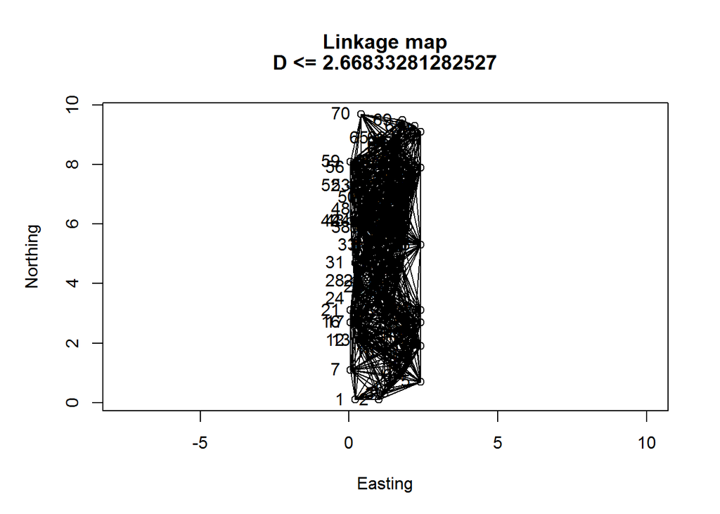

```r
# plot.links() 自备函数, 可绘制连接
plot.links(mite.xy, thresh = dmax.best)
```

```r
# 约束性的冗余分析
# https://www.rdocumentation.org/packages/vegan/versions/2.4-2/topics/cca
(mite.MEM.rda <- rda(mite.h.det~., as.data.frame(MEM.select)))
```

```
## Call: rda(formula = mite.h.det ~ `1` + `2` + `3` + `6` + `8` +
## `9`, data = as.data.frame(MEM.select))
##
##               Inertia Proportion Rank
## Total          0.2823     1.0000
## Constrained    0.0910     0.3223    6
## Unconstrained  0.1913     0.6777   35
## Inertia is variance
##
## Eigenvalues for constrained axes:
##    RDA1    RDA2    RDA3    RDA4    RDA5    RDA6
## 0.05570 0.02186 0.00669 0.00395 0.00273 0.00006
##
## Eigenvalues for unconstrained axes:
##     PC1     PC2     PC3     PC4     PC5     PC6     PC7     PC8
## 0.04605 0.02610 0.01835 0.01182 0.01143 0.00952 0.00816 0.00758
## (Showing 8 of 35 unconstrained eigenvalues)
```

```r
(mite.MEM.R2a <- RsquareAdj(mite.MEM.rda)$adj.r.squared)
```

```
## [1] 0.2577459
```

```r
anova(mite.MEM.rda)
```

```
## Permutation test for rda under reduced model
## Permutation: free
## Number of permutations: 999
##
## Model: rda(formula = mite.h.det ~ `1` + `2` + `3` + `6` + `8` + `9`, data = as.data.frame(MEM.select))
##          Df Variance      F Pr(>F)
## Model     6 0.090998 4.9933  0.001 ***
## Residual 63 0.191351
## ---
## Signif. codes:  0 '***' 0.001 '**' 0.01 '*' 0.05 '.' 0.1 ' ' 1
```

```r
(axes.MEM.test <- anova(mite.MEM.rda, by = "axis"))
```

```
## Permutation test for rda under reduced model
## Forward tests for axes
## Permutation: free
## Number of permutations: 999
##
## Model: rda(formula = mite.h.det ~ `1` + `2` + `3` + `6` + `8` + `9`, data = as.data.frame(MEM.select))
##          Df Variance       F Pr(>F)
## RDA1      1 0.055704 18.3397  0.001 ***
## RDA2      1 0.021863  7.1983  0.001 ***
## RDA3      1 0.006688  2.2020  0.273
## RDA4      1 0.003954  1.3020  0.685
## RDA5      1 0.002732  0.8996  0.851
## RDA6      1 0.000056  0.0185  1.000
## Residual 63 0.191351
## ---
## Signif. codes:  0 '***' 0.001 '**' 0.01 '*' 0.05 '.' 0.1 ' ' 1
```

```r
# 显著性轴的数量
(nb.ax <-
  length(which(axes.MEM.test[ ,ncol(axes.MEM.test)] <=  0.05)))
```

```
## [1] 2
```

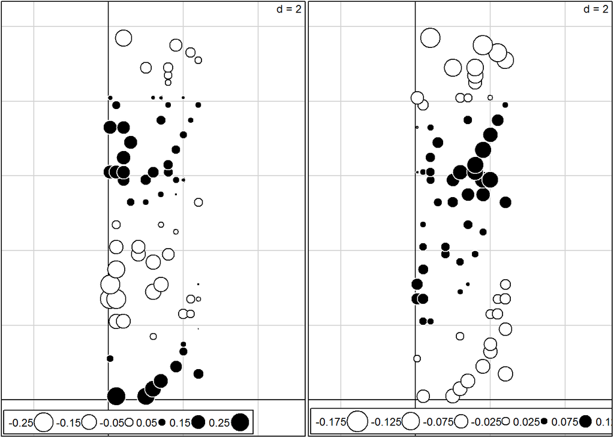

```r
# 绘制显著性的典范轴 - canonical axis
# 质心化 - 中心化处理矩阵(数据框)数据 - Centring
# scale() 对矩阵相似对象进行缩放或者居中
# https://www.rdocumentation.org/packages/base/versions/3.6.0/topics/scale
# 默认 center = T, 减去列平均值然后 centered
# center = F, 减去列平均值
mite.MEM.axes <-
  scores(mite.MEM.rda,
         choices = 1:nb.ax,
         display = "lc",
         scaling = 1)

if(nb.ax <=  2) {
  par(mfrow = c(1,2))
  } else {
  par(mfrow = c(2,2))
  }

for(i in 1:ncol(mite.MEM.axes)) {
  sr.value(mite.xy, mite.MEM.axes[ ,i])
  }
```

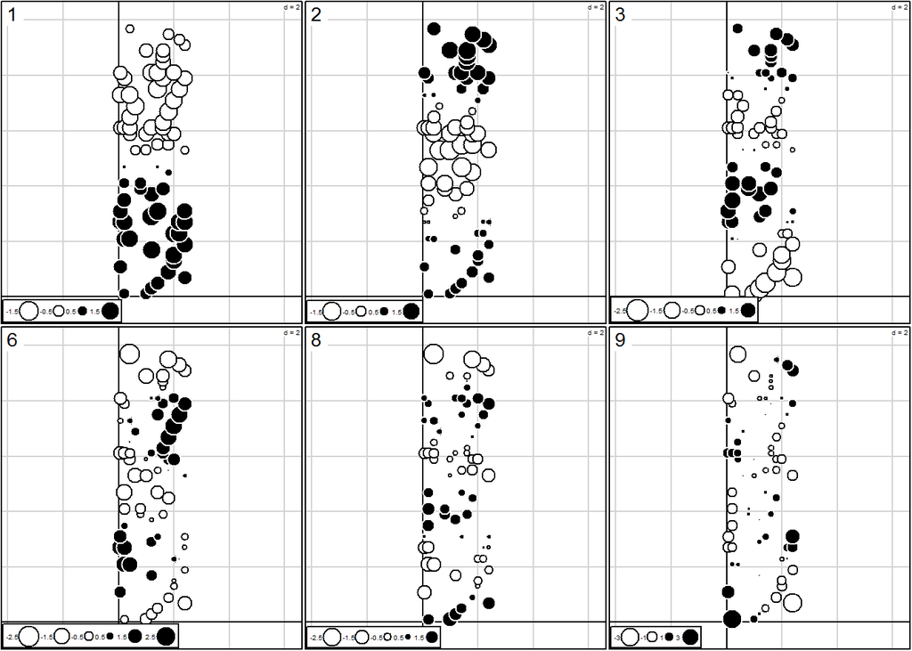

```r
# 绘制显著性的 MEM 变量(Moran 特征向量图分析)
if(ncol(MEM.select) <=  6) {
  par(mfrow = c(2,3))
  }  else  {
    par(mfrow = c(3,3))
  }

for(i in 1:ncol(MEM.select)) {
 sr.value(mite.xy,
          MEM.select[ ,i],
          sub = sort(MEMid)[i],
          csub = 2)
  }
```

```r
# 计算 the retained MEM & dbMEM variables 之间的相关性
cor(MEM.select, dbmem.red) # 计算相关关系 & 方差 & 协方差
```

```
##          MEM1        MEM3        MEM4        MEM6        MEM7        MEM10
## 1 0.200882673  0.17480078  0.02755101 -0.18082991 -0.08951308  0.001806942
## 2 0.832018379 -0.08768451 -0.34232856 -0.21970167  0.07107283 -0.084689081
## 3 0.351511621  0.14511916  0.64964624  0.06433884 -0.44555715  0.068944590
## 6 0.005920702  0.32235252 -0.08050833  0.27954297 -0.35504562  0.063631867
## 8 0.218413658  0.04702488  0.21662159  0.49291676  0.38172577 -0.158730102
## 9 0.010220176 -0.26416771 -0.02795541  0.14921467 -0.21190346 -0.144097595
##         MEM11        MEM20
## 1 -0.02712691 -0.007376879
## 2 -0.03869862 -0.024746611
## 3  0.19612158 -0.030301982
## 6  0.23334638  0.015353582
## 8 -0.25837466  0.049796770
## 9 -0.25978889  0.005908077
```

#### 7.4.3.3 其他类型的连通矩阵

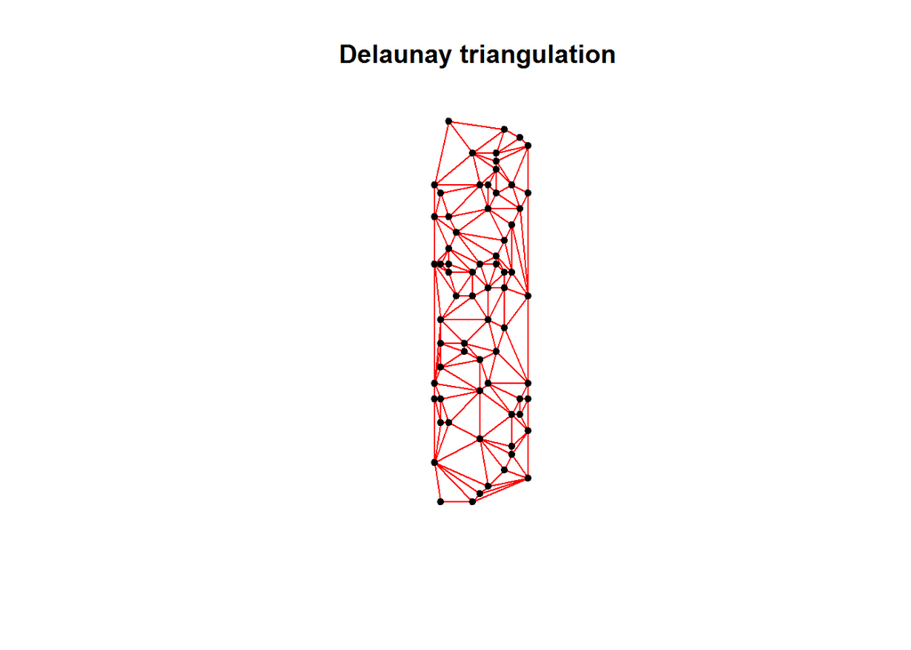

```r
# 连通性递减顺序的连接矩阵的示例
# 所有这些邻域矩阵都存储在 objects of class nb Delaunay triangulation (如前文示例所述)
mite.del <- tri2nb(mite.xy)
# Gabriel graph
# https://www.rdocumentation.org/packages/spdep/versions/1.1-2/topics/graphneigh
# graph2nb - 基于图的空间权重
mite.gab <- graph2nb(gabrielneigh(as.matrix(mite.xy)), sym = TRUE)
# Relative neighbourhood
mite.rel <- graph2nb(relativeneigh(as.matrix(mite.xy)), sym = TRUE)
# Minimum spanning tree
# https://www.rdocumentation.org/packages/adespatial/versions/0.3-4/topics/mst.nb
# mst.nb - 基于最小生成树计算邻域的函数
mite.mst <- mst.nb(dist(mite.xy))

# 绘制连通矩阵
# par(mfrow = c(2,2))
plot(mite.del, mite.xy, col = "red", pch = 20, cex = 1)
title(main = "Delaunay triangulation ")
```

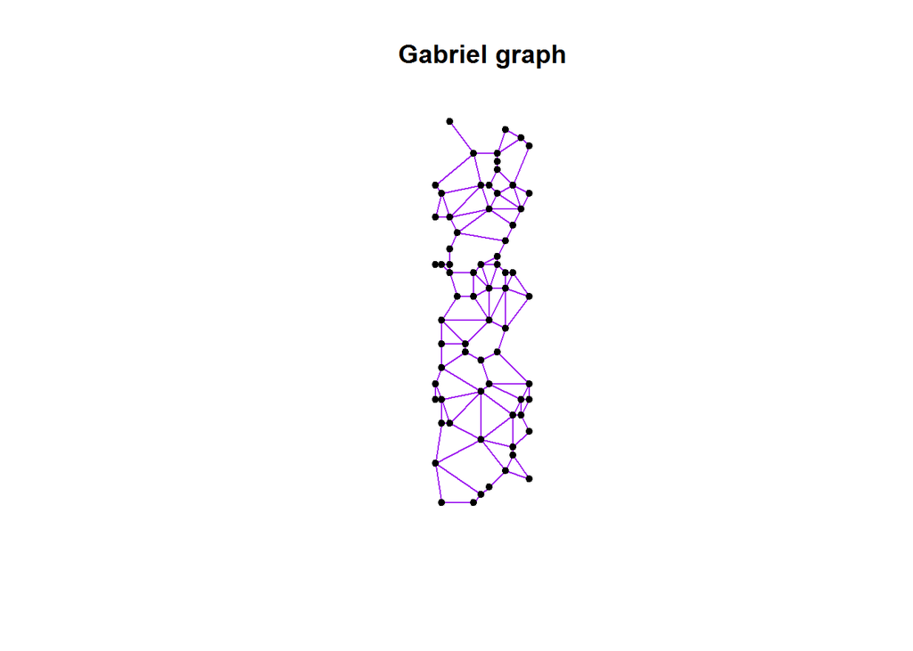

```r
plot(mite.gab, mite.xy, col = "purple", pch = 20, cex = 1)
title(main = "Gabriel graph")
```

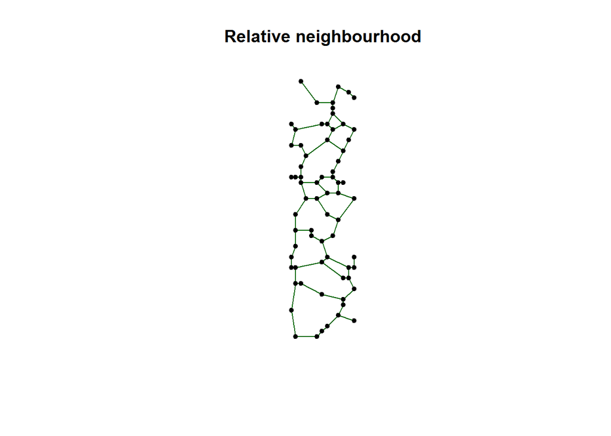

```r
plot(mite.rel, mite.xy, col = "dark green", pch = 20, cex = 1)
title(main = "Relative neighbourhood")
```

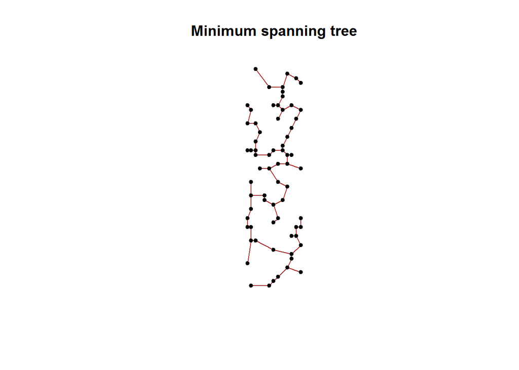

```r
plot(mite.mst, mite.xy, col = "brown", pch = 20, cex = 1)
title(main = "Minimum spanning tree")
```

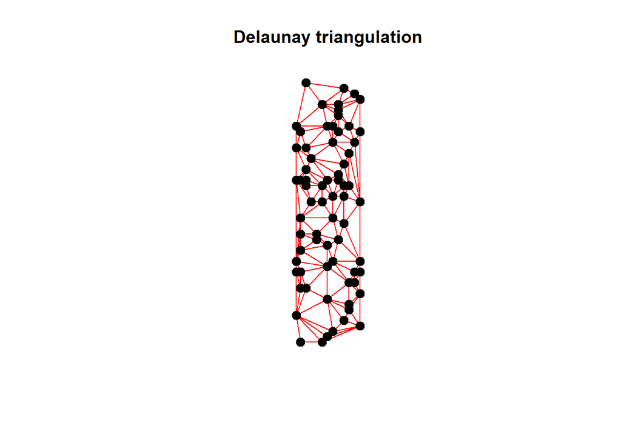

```r
# 编辑连接
# 1. 交互 - Interactive:
plot(mite.del, mite.xy, col = "red", pch = 20, cex = 2)
title(main = "Delaunay triangulation")
```

```r
# 交互性删除
# https://www.rdocumentation.org/packages/spdep/versions/1.1-2/topics/edit.nb
# 邻近列表的交互式编辑
mite.del2 <- edit.nb(mite.del, mite.xy)
```

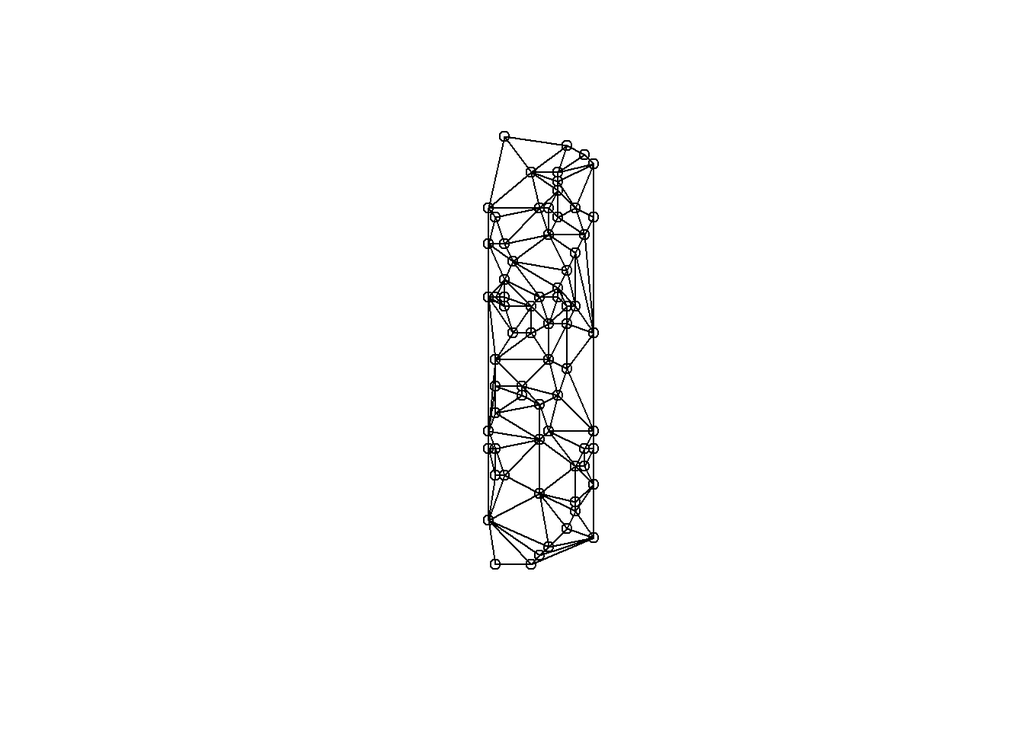

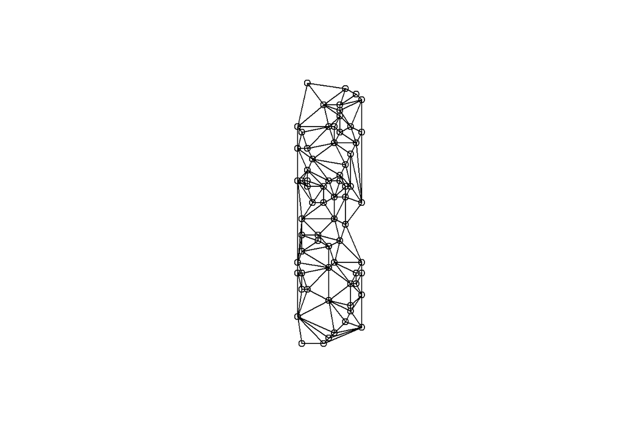

```r
# 2. 也可以通过命令行进行删改
# nb2mat - 邻近列表的空间权重矩阵
# https://www.rdocumentation.org/packages/spdep/versions/1.1-2/topics/nb2mat
mite.del.mat <- nb2mat(mite.del, style = "B")
# 移除连接关系
mite.del.mat[23,35] <- 0
mite.del.mat[35,23] <- 0
# 数据类型的反向转换 Back-conversion
# neig - 邻域图
# https://www.rdocumentation.org/packages/ade4/versions/1.7-13/topics/neig
mite.del3 <- neig2nb(neig(mat01 = mite.del.mat))

plot(mite.del3, mite.xy)
```

```r
# Delaunay triangulation: 数据的核心邻近的列表 ?
mite.del[[23]]      # 编辑之前
```

```
## [1] 18 19 22 27 30 35
```

```r
mite.del2[[23]]     # 交互编辑之后
```

```
## [1] 18 19 22 27 30 35
```

```r
mite.del3[[23]]     # 命令行编辑之后
```

```
## [1] 18 19 22 27 30
```

```r
# 基于距离的连通矩阵(点周围半径)
# 使用相同的截断距离(truncation distance) dmin 作为 dbMEM 示例 (1.011187).
dmin = 1.011187
# https://www.rdocumentation.org/packages/spdep/versions/1.1-2/topics/dnearneigh
# Neighbourhood Contiguity By Distance - 邻里邻接距离
mite.thresh4 <- dnearneigh(as.matrix(mite.xy), 0, dmin * 4)
# Display some values
# Spatial Weights Matrices For Neighbours Lists - 邻近列表的空间权重矩阵
# https://www.rdocumentation.org/packages/spdep/versions/1.1-2/topics/nb2mat
nb2mat(mite.thresh4)[1:10,1:10]
```

```
##          [,1]       [,2]       [,3]       [,4]       [,5]       [,6]
## 1  0.00000000 0.03846154 0.03846154 0.03846154 0.03846154 0.03846154
## 2  0.03703704 0.00000000 0.03703704 0.03703704 0.03703704 0.03703704
## 3  0.03571429 0.03571429 0.00000000 0.03571429 0.03571429 0.03571429
## 4  0.03448276 0.03448276 0.03448276 0.00000000 0.03448276 0.03448276
## 5  0.03571429 0.03571429 0.03571429 0.03571429 0.00000000 0.03571429
## 6  0.03333333 0.03333333 0.03333333 0.03333333 0.03333333 0.00000000
## 7  0.03225806 0.03225806 0.03225806 0.03225806 0.03225806 0.03225806
## 8  0.03125000 0.03125000 0.03125000 0.03125000 0.03125000 0.03125000
## 9  0.02941176 0.02941176 0.02941176 0.02941176 0.02941176 0.02941176
## 10 0.02777778 0.02777778 0.02777778 0.02777778 0.02777778 0.02777778
##          [,7]       [,8]       [,9]      [,10]
## 1  0.03846154 0.03846154 0.03846154 0.03846154
## 2  0.03703704 0.03703704 0.03703704 0.03703704
## 3  0.03571429 0.03571429 0.03571429 0.03571429
## 4  0.03448276 0.03448276 0.03448276 0.03448276
## 5  0.03571429 0.03571429 0.03571429 0.03571429
## 6  0.03333333 0.03333333 0.03333333 0.03333333
## 7  0.00000000 0.03225806 0.03225806 0.03225806
## 8  0.03125000 0.00000000 0.03125000 0.03125000
## 9  0.02941176 0.02941176 0.00000000 0.02941176
## 10 0.02777778 0.02777778 0.02777778 0.00000000
```

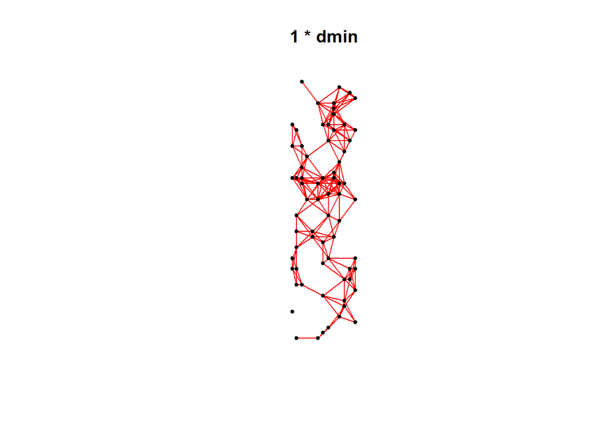

```r
# 使用更短的距离 (1 * dmin, 2 * dmin)
# https://www.rdocumentation.org/packages/spdep/versions/1.1-2/topics/dnearneigh
# Neighbourhood Contiguity By Distance - 邻里邻接距离
mite.thresh1 <- dnearneigh(as.matrix(mite.xy), 0, dmin * 1)
mite.thresh2 <- dnearneigh(as.matrix(mite.xy), 0, dmin * 2)
# 使用长一点的距离
mite.thresh8 <- dnearneigh(as.matrix(mite.xy), 0, dmin * 8)

# par(mfrow = c(1,2))
plot(mite.thresh1, mite.xy, col = "red", pch = 20, cex = 0.8)
title(main = "1 * dmin")
```

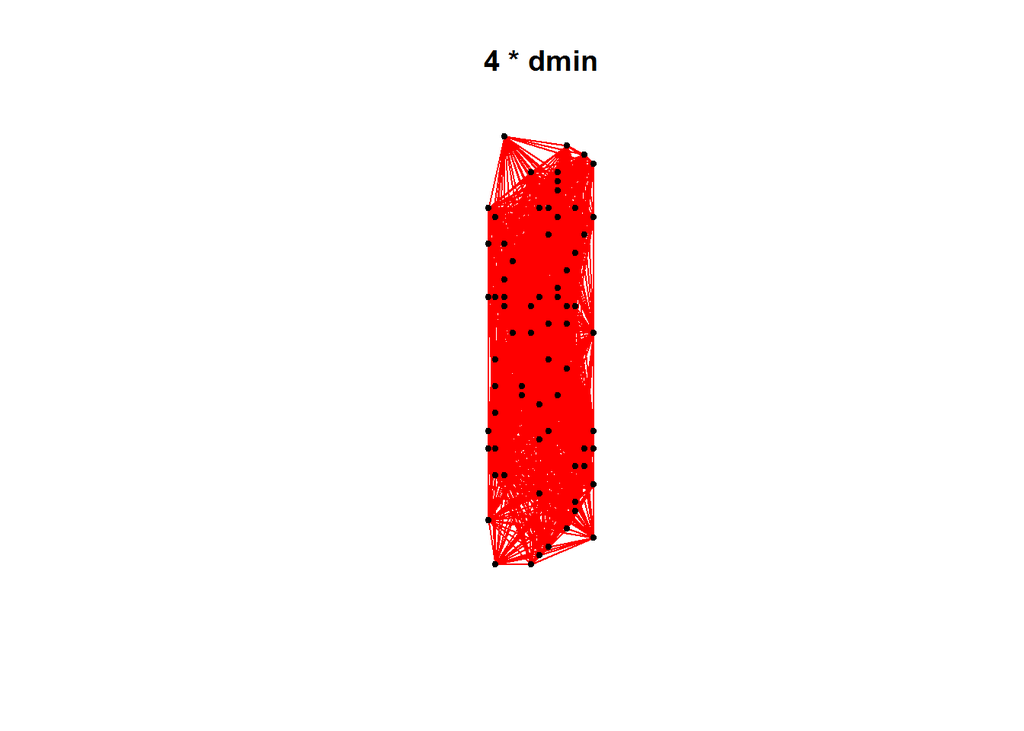

```r
plot(mite.thresh4, mite.xy, col = "red", pch = 20, cex = 0.8)
title(main = "4 * dmin")
```

```r
# 对象之间的转换 - a "nb" object into a "listw" object
# https://www.rdocumentation.org/packages/spdep/versions/1.1-2/topics/nb2listw
# nb2listw - 邻近列表的空间权重
mite.thresh4.lw <- nb2listw(mite.thresh4, style = "B")
# listw2mat - 邻近列表的空间权重
# https://www.rdocumentation.org/packages/spdep/versions/1.1-2/topics/nb2mat
print(listw2mat(mite.thresh4.lw)[1:10,1:10], digits = 1)
```

```
##    [,1] [,2] [,3] [,4] [,5] [,6] [,7] [,8] [,9] [,10]
## 1     0    1    1    1    1    1    1    1    1     1
## 2     1    0    1    1    1    1    1    1    1     1
## 3     1    1    0    1    1    1    1    1    1     1
## 4     1    1    1    0    1    1    1    1    1     1
## 5     1    1    1    1    0    1    1    1    1     1
## 6     1    1    1    1    1    0    1    1    1     1
## 7     1    1    1    1    1    1    0    1    1     1
## 8     1    1    1    1    1    1    1    0    1     1
## 9     1    1    1    1    1    1    1    1    0     1
## 10    1    1    1    1    1    1    1    1    1     0
```